# week2_1intro_to_Cox_model

Hippo

2020_05_25_13

## intro

- KM and log rank test can only use 1 predictor
- Cox is a type of regression, can take multiple predictors
- Cox proportional hazard model (aka Cox regression)

## model assumes proportional hazards

### hazard

- hazard = risk of death (or outcome of interest) at a given moment in time
- e.g. chemotherapy clinical trial
- hazard not going to be same as time goes on
- hazard function/ rate = how hazard changes over time
- e.g. if logarithmic, then 2% die on first day, 1% die on second day etc… and plateaus out

### proportional

- e.g. young vs elderly, 2 groups with different hazard functions

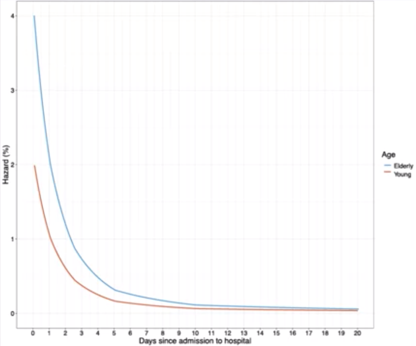

- how to summarize the relation between 2 hazard functions
- i.e. how much more likely are elderly more likely to die vs young?
- hazards are proportional here, can summarize relation with 1 number
- for every time point, you can multiply hazard of young by (e.g. 2), and get hazard for the elderly
- hazard ratio
- proportional hazards assumption must be met (will show how to test assumption later)

## hazard function and risk set

- hazard function h(t) = probability of event happening at time t, given it has not happened
- e.g. h(t) = probability of dying at time t, having survived up to time t
- no easy way to compute h(t) by hand…
- details see http://data.princeton.edu/wws509/notes/c7s1.html

### risk set

- number of subjects at risk changes over time
- risk set at time t = set of patients at time t at risk of experiencing event
- survival analysis methods different by how they define the risk set (e.g. handle censored subjects)

## hazard

- KM plot and log-rank test give you p-value, no effect size
- hazard ratio = effect size, how likely one group will die vs another